# Prediction using Practical Machine Learning

Offikial Developer

April 1, 2016

# Synopsis

## Background

Using devices such as Jawbone Up, Nike FuelBand, and Fitbit it is now possible to collect a large amount of data about personal activity relatively inexpensively.

These type of devices are part of the quantified self movement – a group of enthusiasts who take measurements about themselves regularly to improve their health, to find patterns in their behavior, or because they are tech geeks.

One thing that people regularly do is quantify how much of a particular activity they do, but they rarely quantify how well they do it.

In this project, the goal will be to use data from accelerometers on the belt, forearm, arm, and dumbell of 6 participants. They were asked to perform barbell lifts correctly and incorrectly in 5 different ways.

More information is available from the website here: http://groupware.les.inf.puc-rio.br/har (see the section on the Weight Lifting Exercise Dataset).

## Data

The training data for this project are available here: https://d396qusza40orc.cloudfront.net/predmachlearn/pml-training.csv

The test data are available here: https://d396qusza40orc.cloudfront.net/predmachlearn/pml-testing.csv

The data for this project come from this source: http://groupware.les.inf.puc-rio.br/har.

If you use this document for any purpose please cite them as they have been very generous in allowing their data to be used for this project.

## Submission

### Executive Summary

# Data-Processing

```r
# install.packages("caret")
#
# install.packages("rpart")
# install.packages("rpart.plot")

# install.packages("(randomForest")
```

```r
library(caret)
library(rpart)
```

```r
library(rpart.plot)
library(randomForest)
set.seed(1)
```

## Download the data

```r
urlTraining <- "http://d396qusza40orc.cloudfront.net/predmachlearn/pml-training.csv"
urlTest <- "http://d396qusza40orc.cloudfront.net/predmachlearn/pml-testing.csv"

trainingSet <- read.csv(url(urlTraining), na.strings=c("NA","#DIV/0!",""))
testSet <- read.csv(url(urlTest), na.strings=c("NA","#DIV/0!",""))
```

## Process the data

partition the data

```r
partition <- createDataPartition(trainingSet$classe, p=0.6, list=FALSE)
training  <- trainingSet[partition,]
testing   <- trainingSet[-partition,]
```

clean the data

```r
nzv <- nearZeroVar(training)
training <- training[, -nzv]
testing  <- testing[, -nzv]

na <- sapply(training, function(x) mean(is.na(x))) > 0.75
training <- training[, na==F]
testing  <- testing[, na==F]
```

# Data-Analysis

## Analyse the data

Fit the data (using cross validation)

```r
fit <- train(classe ~ ., data=training, method="rf",
             trControl=trainControl(method="cv", number=3, verboseIter=F))
```

Model the data

```r
model <- fit$finalModel
```

## Prediction

```r
prediction <- predict(fit, newdata=testing)
```

# Results

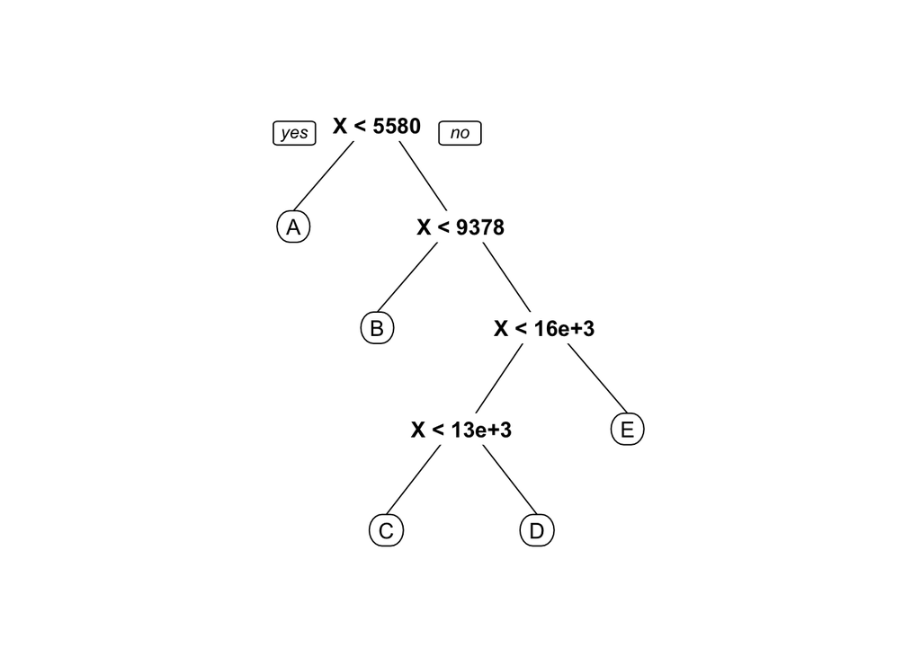

```r
decisionTree <- rpart(classe ~ ., data=training, method="class")
prp(decisionTree)
```